# Custom Vision vs Own Model for object detection

### Cel :

Celem naszego projektu jest wytrenewanie, zapoznanie się z modelami dla wykrywanie obiektów:

1. Azure Custom Vision
2. Mask R-CNN  
   oraz porównanie własnoręcznie wytrenowanych modeli z usługą udostępnioną przez Microsoft.

**Azure Custom Vision** dostarcza możliwość wykorzystania dwóch rodzai modeli do widzenia komputerowego:

- modelu do klasyfikacji obrazów oraz
- modelu do detekcji obiektów.  
  W naszym projekcie wykorzystaliśmy drugi typ, ponieważ skupiamy się na wykrywaniu różnego rodzaju obiektów występujących na zdjęciach.

**Mask R-CNN ResNet-50 FPN**. Do trenowania tego modelu wykorzystaliśmy bibliotekę Pytorch. Zdecydowaliśmy się na wybór tego modelu ze względu na to, że w dokumentacji wspomnianej biblioteki Pytorch osiąga on najlepsze rezultaty z dostępnych modeli.

[figure not shown]

**Image 1** - Porównanie

### Zbiory danych:

W celu porówniania działania obu serwisów sprawdziliśmy trzy zbiory danych:

- Monkey, Cat and Dog detection (30 MB) - [Kaggle](https://www.kaggle.com/tarunbisht11/yolo-animal-detection-small),
- Fruit Images for Object Detection (28 MB) - [Kaggle](https://www.kaggle.com/mbkinaci/fruit-images-for-object-detection?select=train_zip)
- Card detection (38,6 MB) - [Github](https://github.com/EdjeElectronics/TensorFlow-Object-Detection-API-Tutorial-Train-Multiple-Objects-Windows-10/tree/master/images)

Poniżej zostały dostarczone wytrenowane modeli na wyżej omówionych zbiorach danych.

# Azure Machine Learning Configuration

Poniżej zostały dostarczone wytrenowane modeli na wyżej omówionych zbiorach danych.

Podłączanie bibliotek i pakietów:

```python
import azureml.core
from azureml.core import Workspace
from dotenv import set_key, get_key, find_dotenv
from pathlib import Path
from utilities import get_auth
```

Pokazanie poprawnego podłączenie do Workspace Azure. Wyświetlenie wersji:

```python
print("You are currently using version", azureml.core.VERSION, "of the Azure ML SDK")
```

```
You are currently using version 1.17.0 of the Azure ML SDK
```

Konfiguracja Azure oraz environment

```python
import os
subscription_id = os.environ['SUB_ID']
resource_group = "ProjektAzure"
workspace_name = "ProjektAzure"
workspace_region = "East US"
```

Znajdowanie zasobu oraz podłączenie po przez kluczy oraz subskrypcje:

```python
env_path = find_dotenv()
if env_path == "":
    Path(".env").touch()
    env_path = find_dotenv()
```

```python
set_key(env_path, "subscription_id", subscription_id)
set_key(env_path, "resource_group", resource_group)
set_key(env_path, "workspace_name", workspace_name)
set_key(env_path, "workspace_region", workspace_region)
```

```
(True, 'workspace_region', 'East US')
```

Stworzenie roboczego obszaru przy użyciu określonych parametrów i zapisanie szczegółów obszaru roboczego do pliku konfiguracyjnego:

```python
# Create the workspace using the specified parameters
ws = Workspace.create(
    name=workspace_name,
    subscription_id=subscription_id,
    resource_group=resource_group,
    location=workspace_region,
    create_resource_group=True,
    auth=get_auth(env_path),
    exist_ok=True,
)

# write the details of the workspace to a configuration file
ws.write_config()
```

Poniżej można zobaczyć informację dotyczące roboczego obszru (jeżeli odkomentować ws.get_details)

```python
# load workspace configuration
ws = Workspace.from_config(auth=get_auth(env_path))
#ws.get_details()
```

Poniżej jest importowanie bibliotek oraz podłączenie ścieżki do plików, które wskazują na moduły:

```python
import sys

sys.path.append("scripts")
sys.path.append("scripts/cocoapi/PythonAPI/")

import azureml.core
from azureml.core import Workspace, Experiment
from azureml.widgets import RunDetails
from azureml.train.dnn import PyTorch

from dotenv import set_key, get_key, find_dotenv
from utilities import get_auth, download_data

import torch
from scripts.XMLDataset import BuildDataset, get_transform
from scripts.maskrcnn_model import get_model

from PIL import Image, ImageDraw
from IPython.display import display

# check core SDK version number
print("Azure ML SDK Version: ", azureml.core.VERSION)
```

```
Azure ML SDK Version:  1.17.0
```

### Implementacja Mask R-CNN model

```python
#UWAGA!UWAGA!UWAGA!
```

```python
%%writefile scripts/XMLDataset.py
import os
import xml.etree.ElementTree as ET
import torch
import transforms as T
from PIL import Image


class BuildDataset(torch.utils.data.Dataset):
    def __init__(self, root,dataset, transforms=None, train=True):
        self.root = root
        self.transforms = transforms
        #self.labels_dict = {'obama': 1}
        #self.labels_dict = {'ace': 1, 'king': 2, 'queen': 3, 'jack': 4, 'ten': 5, 'nine': 6}

#        self.labels_dict = {'cat': 1, 'dog': 2, 'monkey': 3}
#         self.labels_dict['cat'] = 1
#         self.labels_dict['dog'] = 2
#         self.labels_dict['monkey'] = 3
        # load all image files
        if dataset  == "Fruit":
            self.labels_dict = {'apple': 1, 'orange': 2, 'banana': 3}
        elif dataset == "PlayCards":
            self.labels_dict = {'ace': 1, 'king': 2, 'queen': 3, 'jack': 4, 'ten': 5, 'nine': 6}
        else:
            self.labels_dict = {'cat': 1, 'dog': 2, 'monkey': 3}
        if train:
            print(f"Data/{dataset}/JPEGImages")
            print("Data/"+dataset+"/JPEGImages")
            self.imgs_path = os.path.join(root, f"Data/{dataset}/JPEGImages")
            print(type(dataset))
            self.imgs = list(sorted(os.listdir(self.imgs_path)))
            self.xmls_path = os.path.join(root, f"Data/{dataset}/Annotations")
        else:
            self.imgs_path = os.path.join(root, f"Data/{dataset}/JPEGImagesTest")
            self.imgs = list(sorted(os.listdir(self.imgs_path)))
            self.xmls_path = os.path.join(root, f"Data/{dataset}/AnnotationsTest")

#         if train:
#             self.imgs_path = os.path.join(root, "Data/PlayCards/JPEGImages")
#             self.imgs = list(sorted(os.listdir(self.imgs_path)))
#             self.xmls_path = os.path.join(root, "Data/PlayCards/Annotations")
#         else:
#             self.imgs_path = os.path.join(root, "Data/PlayCards/JPEGImagesTest")
#             self.imgs = list(sorted(os.listdir(self.imgs_path)))
#             self.xmls_path = os.path.join(root, "Data/PlayCards/AnnotationsTest")
#         if train:
#             self.imgs_path = os.path.join(root, "Data/monkeyCats/JPEGImages")
#             self.imgs = list(sorted(os.listdir(self.imgs_path)))
#             self.xmls_path = os.path.join(root, "Data/monkeyCats/Annotations")
#         else:
#             self.imgs_path = os.path.join(root, "Data/monkeyCats/JPEGImagesTest")
#             self.imgs = list(sorted(os.listdir(self.imgs_path)))
#             self.xmls_path = os.path.join(root, "Data/monkeyCats/AnnotationsTest")

    def __getitem__(self, idx):
        img_path = os.path.join(self.imgs_path, self.imgs[idx])
        xml_path = os.path.join(
            self.xmls_path, "{}.xml".format(self.imgs[idx].strip(".jpg"))
        )
        img = Image.open(img_path).convert("RGB")

        # parse XML annotation
        tree = ET.parse(xml_path)
        t_root = tree.getroot()

        # get bounding box coordinates
        boxes = []
        labels = []
        for obj in t_root.findall("object"):
            bnd_box = obj.find("bndbox")
            xmin = float(bnd_box.find("xmin").text)
            xmax = float(bnd_box.find("xmax").text)
            ymin = float(bnd_box.find("ymin").text)
            ymax = float(bnd_box.find("ymax").text)
            boxes.append([xmin, ymin, xmax, ymax])
            label_name = str(obj.find("name").text)
#             if self.labels_dict:
#                 if label_name not in self.labels_dict.keys():
#                     self.labels_dict[label_name] = max(self.labels_dict.values()) + 1
#             else:
#                 self.labels_dict[label_name] = 1
#             print(label_name + ": " + str(self.labels_dict[label_name]))
            labels.append(self.labels_dict[label_name])
        num_objs = len(boxes)
        boxes = torch.as_tensor(boxes, dtype=torch.float32)

        # there is only one class
        labels = torch.as_tensor(labels)
#         print(labels)
#         labels = torch.ones((num_objs,), dtype=torch.int64)
        image_id = torch.tensor([idx])

        # area of the bounding box, used during evaluation with the COCO metric for small, medium and large boxes
        area = (boxes[:, 3] - boxes[:, 1]) * (boxes[:, 2] - boxes[:, 0])

        # suppose all instances are not crowd
        iscrowd = torch.zeros((num_objs,), dtype=torch.int64)

        target = {}
        target["boxes"] = boxes
        target["labels"] = labels
        target["image_id"] = image_id
        target["area"] = area
        target["iscrowd"] = iscrowd

        if self.transforms is not None:
            img, target = self.transforms(img, target)

        return img, target

    def __len__(self):
        return len(self.imgs)


def get_transform(train):
    transforms = []
    transforms.append(T.ToTensor())
    if train:
        transforms.append(T.RandomHorizontalFlip(0.5))
    return T.Compose(transforms)
```

```
Overwriting scripts/XMLDataset.py
```

```python
%%writefile scripts/maskrcnn_model.py
import torchvision
from torchvision.models.detection.faster_rcnn import FastRCNNPredictor
from torchvision.models.detection.rpn import AnchorGenerator
from torchvision.models.detection.rpn import RPNHead


def get_model(
    num_classes,
    anchor_sizes,
    anchor_aspect_ratios,
    rpn_nms_threshold,
    box_nms_threshold,
    box_score_threshold,
    num_box_detections,
):

    # load pre-trained mask R-CNN model
    model = torchvision.models.detection.maskrcnn_resnet50_fpn(
        pretrained=True,
        rpn_nms_thresh=rpn_nms_threshold,
        box_nms_thresh=box_nms_threshold,
        box_score_thresh=box_score_threshold,
        box_detections_per_img=num_box_detections,
    )
    # get number of input features for the classifier
    in_features = model.roi_heads.box_predictor.cls_score.in_features

    # replace the pre-trained head with a new one
    model.roi_heads.box_predictor = FastRCNNPredictor(in_features, num_classes)

    anchor_sizes = tuple([float(i) for i in anchor_sizes.split(",")])
    anchor_aspect_ratios = tuple([float(i) for i in anchor_aspect_ratios.split(",")])

    # create an anchor_generator for the FPN which by default has 5 outputs
    anchor_generator = AnchorGenerator(
        sizes=tuple([anchor_sizes for _ in range(5)]),
        aspect_ratios=tuple([anchor_aspect_ratios for _ in range(5)]),
    )
    model.rpn.anchor_generator = anchor_generator

    # get number of input features for the RPN returned by FPN (256)
    in_channels = model.backbone.out_channels

    # replace the RPN head
    model.rpn.head = RPNHead(
        in_channels, anchor_generator.num_anchors_per_location()[0]
    )

    # turn off masks since dataset only has bounding boxes
    model.roi_heads.mask_roi_pool = None

    return model
```

```
Overwriting scripts/maskrcnn_model.py
```

```python
%%writefile scripts/train.py
import os
import sys

sys.path.append("./cocoapi/PythonAPI/")

import torch
import argparse
import utils
from XMLDataset import BuildDataset, get_transform
from maskrcnn_model import get_model
from engine import train_one_epoch, evaluate

if __name__ == "__main__":
    parser = argparse.ArgumentParser(description="PyTorch Object Detection Training")
    parser.add_argument(
        "--data_path", default="./Data/", help="the path to the dataset"
    )
    parser.add_argument("--batch_size", default=2, type=int)
    parser.add_argument(
        "--epochs", default=10, type=int, help="number of total epochs to run"
    )
    parser.add_argument(
        "--workers", default=4, type=int, help="number of data loading workers"
    )
    parser.add_argument(
        "--learning_rate", default=0.005, type=float, help="initial learning rate"
    )
    parser.add_argument("--momentum", default=0.9, type=float, help="momentum")
    parser.add_argument(
        "--weight_decay",
        default=0.0005,
        type=float,
        help="weight decay (default: 1e-4)",
    )
    parser.add_argument(
        "--lr_step_size", default=3, type=int, help="decrease lr every step-size epochs"
    )
    parser.add_argument(
        "--lr_gamma",
        default=0.1,
        type=float,
        help="decrease lr by a factor of lr-gamma",
    )
    parser.add_argument("--print_freq", default=10, type=int, help="print frequency")
    parser.add_argument("--output_dir", default="outputs", help="path where to save")
    parser.add_argument("--anchor_sizes", default="16", type=str, help="anchor sizes")
    parser.add_argument(
        "--anchor_aspect_ratios", default="1.0", type=str, help="anchor aspect ratios"
    )
    parser.add_argument(
        "--rpn_nms_thresh",
        default=0.7,
        type=float,
        help="NMS threshold used for postprocessing the RPN proposals",
    )
    parser.add_argument(
        "--box_nms_thresh",
        default=0.5,
        type=float,
        help="NMS threshold for the prediction head. Used during inference",
    )
    parser.add_argument(
        "--box_score_thresh",
        default=0.05,
        type=float,
        help="during inference only return proposals"
        "with a classification score greater than box_score_thresh",
    )
    parser.add_argument(
        "--box_detections_per_img",
        default=100,
        type=int,
        help="maximum number of detections per image, for all classes",
    )
    parser.add_argument(
        "--num_classes",
        default=4,
        type=int,
        help="namber of classes + 1",
    )
    parser.add_argument(
        "--dataset",
        default="Fruit",
        type=str,
        help="Path to dataset",
    )
    args = parser.parse_args()

data_path = args.data_path

# use our dataset and defined transformations
dataset = BuildDataset(data_path, args.dataset, get_transform(train=True), train=True)
dataset_test = BuildDataset(data_path,args.dataset, get_transform(train=False), train=False)
# dataset_test = BuildDataset(data_path, get_transform(train=False), train=True)

# split the dataset in train and test set
# indices = torch.randperm(len(dataset)).tolist()
# dataset = torch.utils.data.Subset(dataset, range(0, len(dataset)))
# dataset_test = torch.utils.data.Subset(dataset_test, range(0, len(dataset_test)))
# dataset = torch.utils.data.Subset(dataset, indices[:-100])
# dataset_test = torch.utils.data.Subset(dataset_test, indices[-100:])

batch_size = args.batch_size
workers = args.workers

# define training and validation data loaders
data_loader = torch.utils.data.DataLoader(
    dataset,
    batch_size=2,
    shuffle=True,
    num_workers=workers,
    collate_fn=utils.collate_fn,
)

data_loader_test = torch.utils.data.DataLoader(
    dataset_test,
    batch_size=2,
    shuffle=False,
    num_workers=workers,
    collate_fn=utils.collate_fn,
)


# our dataset has two classes only - background and out of stock
num_classes = args.num_classes

model = get_model(
    num_classes,
    args.anchor_sizes,
    args.anchor_aspect_ratios,
    args.rpn_nms_thresh,
    args.box_nms_thresh,
    args.box_score_thresh,
    args.box_detections_per_img,
)




# train on the GPU or on the CPU, if a GPU is not available
device = torch.device("cuda") if torch.cuda.is_available() else torch.device("cpu")

# move model to the right device
model.to(device)

learning_rate = args.learning_rate
momentum = args.momentum
weight_decay = args.weight_decay

# construct an optimizer
params = [p for p in model.parameters() if p.requires_grad]
optimizer = torch.optim.SGD(
    params, lr=learning_rate, momentum=momentum, weight_decay=weight_decay
)

lr_step_size = args.lr_step_size
lr_gamma = args.lr_gamma

# and a learning rate scheduler
lr_scheduler = torch.optim.lr_scheduler.StepLR(
    optimizer, step_size=lr_step_size, gamma=lr_gamma
)

# number of training epochs
num_epochs = args.epochs
print_freq = args.print_freq

for epoch in range(num_epochs):
    # train for one epoch, printing every 10 iterations
    train_one_epoch(model, optimizer, data_loader, device, epoch, print_freq=print_freq)


    # update the learning rate
    lr_scheduler.step()
    # evaluate on the test dataset after every epoch
    #print("EVALUATE!!!!!!!!!!!!!!!!!!!!!!")
    evaluate(model, data_loader_test, device=device)
    evaluate(model, data_loader, device=device)

    #

# save model
if not os.path.exists(args.output_dir):
    os.makedirs(args.output_dir)
torch.save(model.state_dict(), os.path.join(args.output_dir, args.dataset+"model_latest.pth"))

print("That's it!")
```

```
Overwriting scripts/train.py
```

### Trenowanie modelu

```python
import sys

sys.path.append("scripts")
sys.path.append("scripts/cocoapi/PythonAPI/")

import azureml.core
from azureml.core import Workspace, Experiment
from azureml.widgets import RunDetails
from azureml.train.dnn import PyTorch

from dotenv import set_key, get_key, find_dotenv
from utilities import get_auth, download_data

import torch
from scripts.XMLDataset import BuildDataset, get_transform
from scripts.maskrcnn_model import get_model

from PIL import Image, ImageDraw
from IPython.display import display

# check core SDK version number
print("Azure ML SDK Version: ", azureml.core.VERSION)
```

```
Azure ML SDK Version:  1.17.0
```

```python
env_path = find_dotenv(raise_error_if_not_found=True)
```

```python
# data_file = "Data.zip"
# data_url = ("https://bostondata.blob.core.windows.net/builddata/{}".format(data_file))
# download_data(data_file, data_url)
```

```python
ws = Workspace.from_config(auth=get_auth(env_path))
print(ws.name, ws.resource_group, ws.location, sep="\n")
```

```
ProjektAzure
ProjektAzure
eastus
```

```python
exp = Experiment(workspace=ws, name='torchvision')
```

```python
# with open("scripts/train.py", "r") as f:
#     print(f.read())
```

```python
num_epochs = 2
script_params = {
    "--data_path": ".",
    "--workers": 8,
    "--learning_rate": 0.005,
    "--epochs": num_epochs,
    "--anchor_sizes": "16,32,64,128,256,512",
    "--anchor_aspect_ratios": "0.25,0.5,1.0,2.0",
    "--rpn_nms_thresh": 0.5,
    "--box_nms_thresh": 0.3,
    "--box_score_thresh": 0.10,
    "--num_classes":4,
    "--dataset": "Fruit",
}

estimator = PyTorch(
    source_directory="./scripts",
    script_params=script_params,
    compute_target="local",
    entry_script="train.py",
    use_docker=False,
    user_managed=True,
    use_gpu=True,
)
```

```
WARNING - 'use_docker' parameter will be deprecated. Please use 'environment_definition' instead.
```

```python
def prepareEstimator (dataset,clas,num_epochs,outPut_fileName):
    script_params = {
        "--data_path": ".",
        "--workers": 8,
        "--learning_rate": 0.005,
        "--epochs": num_epochs,
        "--anchor_sizes": "16,32,64,128,256,512",
        "--anchor_aspect_ratios": "0.25,0.5,1.0,2.0",
        "--rpn_nms_thresh": 0.5,
        "--box_nms_thresh": 0.3,
        "--box_score_thresh": 0.10,
        "--num_classes": clas,
        "--dataset": dataset,
    }

    estimator = PyTorch(
        source_directory="./scripts",
        script_params=script_params,
        compute_target="local",
        entry_script="train.py",
        use_docker=False,
        user_managed=True,
        use_gpu=True,
    )
    estimator.run_config.environment.python.interpreter_path = ("/anaconda/envs/azureml_py36_pytorch/bin/python")
    estimator.run_config.history.snapshot_project = False
    run = exp.submit(estimator)
    RunDetails(run).show()
    run.wait_for_completion(show_output=True)
    metrics = run.get_metrics()
    run.get_file_names()
    run.register_model(model_name="torchvision_local_model", model_path="/outputs/"+outPut_fileName+"model_latest.pth")
    run.download_file("outputs/"+outPut_fileName+"model_latest.pth")
    return metrics
```

### Łądowanie datasetów

#### DataSet Fruit

```
Arguments
--data_path . --workers 8 --learning_rate 0.005 --epochs 20 --anchor_sizes 16,32,64,128,256,512 --anchor_aspect_ratios 0.25,0.5,1.0,2.0 --rpn_nms_thresh 0.5 --box_nms_thresh 0.3 --box_score_thresh 0.1 --num_classes 4 --dataset Fruit
```

Czas trwania: 1h 54m 18.30s

[figure not shown]

#### DataSet MonkeyCats

```
Arguments
--data_path . --workers 8 --learning_rate 0.005 --epochs 20 --anchor_sizes 16,32,64,128,256,512 --anchor_aspect_ratios 0.25,0.5,1.0,2.0 --rpn_nms_thresh 0.5 --box_nms_thresh 0.3 --box_score_thresh 0.1 --num_classes 4 --dataset monkeyCats
```

Czas trwania: 3h 47m 4.478s

[figure not shown]

#### DataSet PlayCards

```
Arguments
--data_path . --workers 8 --learning_rate 0.005 --epochs 20 --anchor_sizes 16,32,64,128,256,512 --anchor_aspect_ratios 0.25,0.5,1.0,2.0 --rpn_nms_thresh 0.5 --box_nms_thresh 0.3 --box_score_thresh 0.1 --num_classes 7 --dataset PlayCards
```

Czas trwania: 2h 23m 4.841s

[figure not shown]

Poniżej pokazuje metryki wszystkich na jednym wykresie:

**93 - Fruit** **94 - MonkeyCats** **95 - PlayCards**

[figure not shown]

```python
datasetsList = ["Fruit","monkeyCats","PlayCards"]
classesList = [4,4,7]
num_epochs=20
metrics = []
for dataset,clas in zip(datasetsList,classesList):
    metrics.append(prepareEstimator (dataset,clas,num_epochs,dataset))
```

```
WARNING - 'use_docker' parameter will be deprecated. Please use 'environment_definition' instead.
WARNING - If 'script' has been provided here and a script file name has been specified in 'run_config', 'script' provided in ScriptRunConfig initialization will take precedence.
WARNING - If 'arguments' has been provided here and arguments have been specified in 'run_config', 'arguments' provided in ScriptRunConfig initialization will take precedence.
```

[output not shown]

[output cut: 1119 more lines]

[output not shown]

```
WARNING - 'use_docker' parameter will be deprecated. Please use 'environment_definition' instead.
WARNING - If 'script' has been provided here and a script file name has been specified in 'run_config', 'script' provided in ScriptRunConfig initialization will take precedence.
WARNING - If 'arguments' has been provided here and arguments have been specified in 'run_config', 'arguments' provided in ScriptRunConfig initialization will take precedence.
```

[output not shown]

[output cut: 1408 more lines]

```
WARNING - 'use_docker' parameter will be deprecated. Please use 'environment_definition' instead.
WARNING - If 'script' has been provided here and a script file name has been specified in 'run_config', 'script' provided in ScriptRunConfig initialization will take precedence.
WARNING - If 'arguments' has been provided here and arguments have been specified in 'run_config', 'arguments' provided in ScriptRunConfig initialization will take precedence.
```

[output not shown]

[output cut: 1179 more lines]

[output not shown]

```python
with open('metrixs.txt', 'w') as f:
    for item in metrics:
        f.write("%s\n" % item)
```

```python
#UWAGA! UWAGA! UWAGA!
```

### Dokładny opis datasetów

```python
from matplotlib import pyplot as plt
def plotmAP(fileName,dataSets):
    with open(fileName, 'r') as f:
        for line, title in zip(f.readlines(), dataSets):
            dic = eval(line)
            plt.figure(figsize=(10,10))
            plt.plot(dic['mAP@IoU=0.50'][::2])
            plt.plot(dic['mAP@IoU=0.50'][1::2], color="red")
            plt.title(title)
            plt.xlabel("epochs")
            plt.ylabel("mAP@IoU")
            plt.grid()
            plt.show()
```

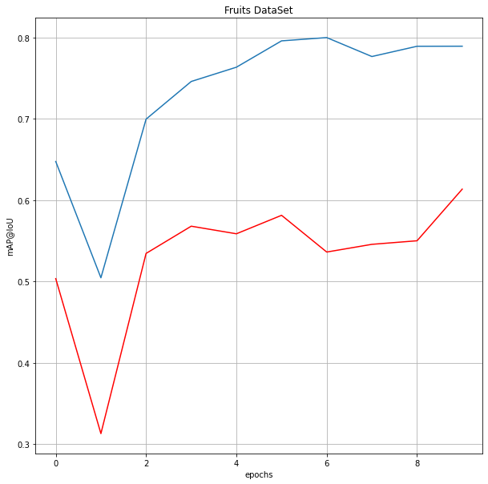

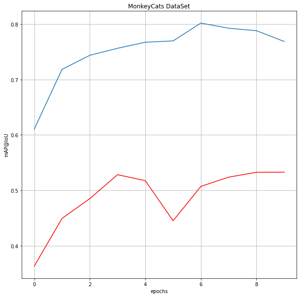

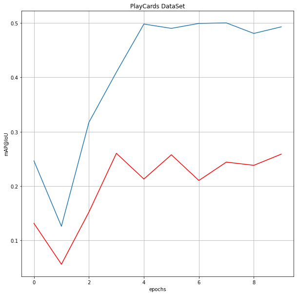

```python
plotmAP("metrixs-1.txt",['Fruits DataSet',  'MonkeyCats DataSet', 'PlayCards DataSet'])
```

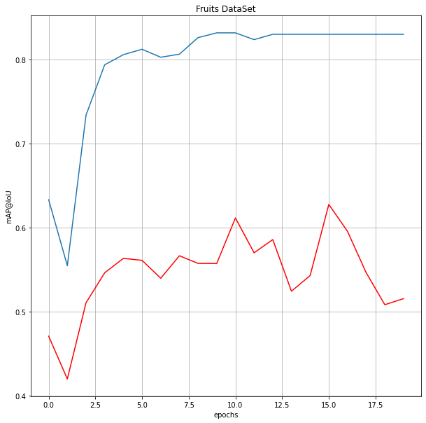

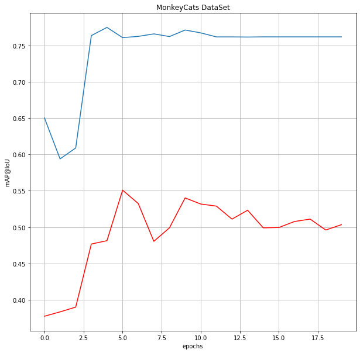

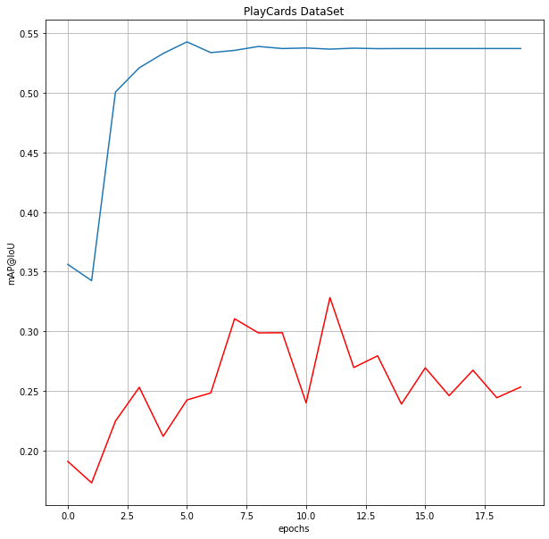

```python
plotmAP("metrixs.txt",['Fruits DataSet',  'MonkeyCats DataSet', 'PlayCards DataSet'])
```

```python
def makePrediction(num_classes,dataset,model_path,index,labels_dict):
    anchor_sizes = "16,32,64,128,256,512"
    anchor_aspect_ratios = "0.25,0.5,1.0,2.0"
    rpn_nms_threshold = 0.5
    box_nms_threshold = 0.3
    box_score_threshold = 0.1
    num_box_detections = 100

    #prepare model to make prediction
    model = get_model(
        num_classes,
        anchor_sizes,
        anchor_aspect_ratios,
        rpn_nms_threshold,
        box_nms_threshold,
        box_score_threshold,
        num_box_detections,
    )
    #model_path = "model_latest.pth"
    model.load_state_dict(torch.load(model_path))
    device = torch.device("cuda") if torch.cuda.is_available() else torch.device("cpu")
    model.to(device)

    # Use a random subset of the data to visualize predictions on the images.
    data_path = "./scripts"
    #dataset = BuildDataset(data_path, "Fruit" ,get_transform(train=False), train=False)
    dataset = BuildDataset(data_path, dataset ,get_transform(train=False), train=False)
    #prediction
    img, _ = dataset[index]
    model.eval()
    with torch.no_grad():
        prediction = model([img.to(device)])
    img = Image.fromarray(img.mul(255).permute(1, 2, 0).byte().numpy())
    preds = prediction[0]["boxes"].cpu().numpy()
    print(prediction[0]["scores"])
    print(prediction[0]['labels'])
    draw = ImageDraw.Draw(img)
    for i in range(len(preds)):
        if prediction[0]["scores"][i].item() > 0.5:
            draw.rectangle(
                ((preds[i][0], preds[i][1]), (preds[i][2], preds[i][3])), outline="red"
            )
            draw.text((preds[i][0], preds[i][1]), labels_dict[prediction[0]['labels'][i].item()], fill=(52, 55, 235,128))
    display(img)
```

# Porównanie Mask R-CNN z Custom Vision

## Dataset Fruits

Po wytrenowaniu Custom Vision otrzymaliśmy takie wyniki dla datasetu Fruits:

- **Precision** - jak prawdopodobne jest, że jest to prawda?
- **Recall** - spośród tagów, które należy prawidłowo przewidzieć, jaki procent poprawnie znalazł twój model?
- **mAP** - (średnia dokładność) ogólna wydajność detektora obiektów we wszystkich znacznikach

[figure not shown]

Przykład wykrywania objektu na zdjęciu. Jest pokazane, że to jest banan.

### Custom Vision

Zdjęcie dla Custom Vision:

[figure not shown]

Predition:

[figure not shown]

### Mask R-CNN

```
tensor([0.8869, 0.4075, 0.2982], device='cuda:0')
tensor([3, 1, 3], device='cuda:0')
```

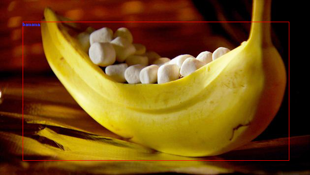

```python
#Można pobawić się z predykcją
labels_dict = {1: 'apple', 2: 'orange', 3: 'banana'}
makePrediction(4,"Fruit","Fruitmodel_latest.pth",25,labels_dict)
```

# Wnioski z przykładu

Zdjęcie z bananem wyszło nam, że dla Custom Vision jest 36.2% prawdopodobieństwa, natomiast dla Mask R-CNN wychodzi 88.69% prawdopodobeństwa.

**W tym wypadku Mask R-CNN pokazał siebie z lepszej strony**

## Dataset Monkey Cat Dog

Po wytrenowaniu Custom Vision otrzymaliśmy takie wyniki dla datasetu Monkey Cat Dog:

- **Precision** - jak prawdopodobne jest, że jest to prawda?
- **Recall** - spośród tagów, które należy prawidłowo przewidzieć, jaki procent poprawnie znalazł twój model?
- **mAP** - (średnia dokładność) ogólna wydajność detektora obiektów we wszystkich znacznikach

[figure not shown]

### Custom Vision

Zdjęcie dla Custom Vision:

[figure not shown]

Predition:

[figure not shown]

### Mask R-CNN

```
tensor([0.9081, 0.4157], device='cuda:0')
tensor([3, 1], device='cuda:0')
```

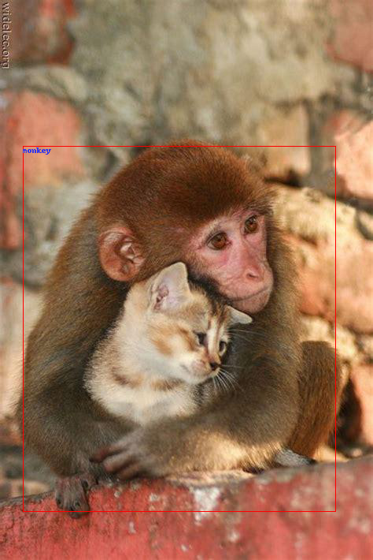

```python
labels_dict = {1: "cat", 2: "dog", 3: "monkey"}
makePrediction(4,"monkeyCats","monkeyCatsmodel_latest1.pth",11,labels_dict)
```

# Wnioski z przykładu

Zdjęcie z małpą oraz kotem wyszło nam, że dla Custom Vision Kot(**74.2%**) a małpa(**86.6%**) prawdopodobieństwa, natomiast dla Mask R-CNN nie wykrał w ogóle kota, a tylko małpę(**90%**)

**W tym wypadku Custom Vision pokazał siebie z lepszej strony** Czyli dla wykrywanie jednego objektu na zdjęciu radzi sobie lepiej Mask R-CNN, natomiast Custom Vision wykrawa lepiej zdjęcia z dwoma lub więcej objektami.

## Dataset Play Cards

- **Precision** - jak prawdopodobne jest, że jest to prawda?
- **Recall** - spośród tagów, które należy prawidłowo przewidzieć, jaki procent poprawnie znalazł twój model?
- **mAP** - (średnia dokładność) ogólna wydajność detektora obiektów we wszystkich znacznikach

# Wnioski z przykładu

Na zbiorze danych Play Cards wykryło dwa asy ( czyli pozytywnie). Z powodu zmiany predykcji z 4 na 7.

```
tensor([0.8226, 0.5251, 0.1733, 0.1463], device='cuda:0')
tensor([1, 1, 5, 6], device='cuda:0')
```

[figure not shown]

```python
labels_dict = {1: 'ace', 2: 'king', 3: 'queen', 4: 'jack', 5: 'ten', 6: 'nine'}
makePrediction(7,"PlayCards","PlayCardsmodel_latest1.pth",55,labels_dict)
```

```python
num_classes = 4
anchor_sizes = "16,32,64,128,256,512"
anchor_aspect_ratios = "0.25,0.5,1.0,2.0"
rpn_nms_threshold = 0.5
box_nms_threshold = 0.3
box_score_threshold = 0.1
num_box_detections = 100
```

```python
# Load Mask RCNN model
model = get_model(
    num_classes,
    anchor_sizes,
    anchor_aspect_ratios,
    rpn_nms_threshold,
    box_nms_threshold,
    box_score_threshold,
    num_box_detections,
)
```

```python
model_path = "model_latest.pth"
model.load_state_dict(torch.load(model_path))
device = torch.device("cuda") if torch.cuda.is_available() else torch.device("cpu")
model.to(device)
```

[output not shown]

[output cut: 177 more lines]

[output not shown]

```python
# Use a random subset of the data to visualize predictions on the images.
data_path = "./scripts"
dataset = BuildDataset(data_path, "Fruit" ,get_transform(train=False), train=False)
# indices = torch.randperm(len(dataset)).tolist()
# dataset = torch.utils.data.Subset(dataset, indices[-50:])
```

```python
# for i in range(5):
#     img, _ = dataset[i]
#     model.eval()
#     with torch.no_grad():
#         prediction = model([img.to(device)])
#     img = Image.fromarray(img.mul(255).permute(1, 2, 0).byte().numpy())
#     preds = prediction[0]["boxes"].cpu().numpy()
#     print(prediction[0]["scores"])
#     draw = ImageDraw.Draw(img)
#     for i in range(len(preds)):
#         draw.rectangle(
#             ((preds[i][0], preds[i][1]), (preds[i][2], preds[i][3])), outline="red"
#         )
#     display(img)
```

```python
img, _ = dataset[1]
model.eval()
with torch.no_grad():
    prediction = model([img.to(device)])
img = Image.fromarray(img.mul(255).permute(1, 2, 0).byte().numpy())
preds = prediction[0]["boxes"].cpu().numpy()
print(prediction[0])
```

```
{'boxes': tensor([[  9.2525,  24.6268, 350.0000, 340.1003]], device='cuda:0'), 'labels': tensor([1], device='cuda:0'), 'scores': tensor([0.6061], device='cuda:0')}
```

```python
labels_dict = {1: 'apple', 2: 'orange', 3: 'banana'}

#labels_dict = {1: 'ace', 2: 'king', 3: 'queen', 4: 'jack', 5: 'ten', 6: 'nine'}

#labels_dict = {1: "cat", 2: "dog", 3: "monkey"}
```

### Custom Vision

Zdjęcie dla Custom Vision:

[figure not shown]

```
tensor([0.8912], device='cuda:0')
tensor([1], device='cuda:0')
```

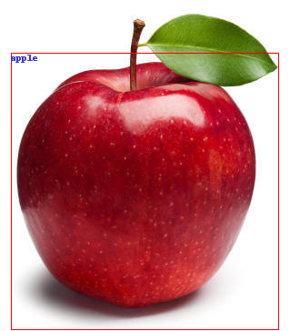

```python
img, _ = dataset[12]
model.eval()
with torch.no_grad():
    prediction = model([img.to(device)])
img = Image.fromarray(img.mul(255).permute(1, 2, 0).byte().numpy())
preds = prediction[0]["boxes"].cpu().numpy()
print(prediction[0]["scores"])
print(prediction[0]['labels'])
draw = ImageDraw.Draw(img)
for i in range(len(preds)):
    if prediction[0]["scores"][i].item() > 0.5:
        draw.rectangle(
            ((preds[i][0], preds[i][1]), (preds[i][2], preds[i][3])), outline="red"
        )
        draw.text((preds[i][0], preds[i][1]), labels_dict[prediction[0]['labels'][i].item()], fill=(52, 55, 235,128))
display(img)
```

# Wnioski z przykładu

Zdjęcie z jabłkiem wyszło nam, że dla Custom Vision (**62,4%**) prawdopodobieństwa, natomiast dla Mask R-CNN (**89%**)

**W tym wypadku Mask R-CNN pokazał siebie z lepszej strony** Czyli dla wykrywanie jednego objektu na zdjęciu radzi sobie lepiej Mask R-CNN.

### Custom Vision

Zdjęcie dla Custom Vision:

[figure not shown]

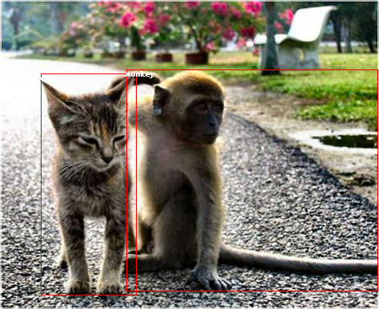

```python
import xml.etree.ElementTree as ET
#tree = ET.parse('scripts/Data/PlayCards/AnnotationsTest/cam_image45.xml')
tree = ET.parse('scripts/Data/monkeyCats/AnnotationsTest/cats_and_monkeys_029.xml')
t_root = tree.getroot()
#img = Image.open('scripts/Data/PlayCards/JPEGImagesTest/cam_image45.jpg')
img = Image.open('scripts/Data/monkeyCats/JPEGImagesTest/cats_and_monkeys_029.jpg')
draw = ImageDraw.Draw(img)
for obj in t_root.findall("object"):
    bnd_box = obj.find("bndbox")
    xmin = float(bnd_box.find("xmin").text)
    xmax = float(bnd_box.find("xmax").text)
    ymin = float(bnd_box.find("ymin").text)
    ymax = float(bnd_box.find("ymax").text)
    label_name = str(obj.find("name").text)
    draw.rectangle(
            ((xmin, ymin), (xmax, ymax)), outline="red"
        )
    draw.text((xmin, ymin), label_name, fill=(255,255,255,128))
display(img)
```

# Wnioski z przykładu

# Ogólne wnioski & porównanie

Wykrywanie obiektów to zadanie w wizji komputerowej, które obejmuje identyfikację obecności, lokalizacji i typu jednego lub więcej obiektów na danym zdjęciu.

Stworzyliśmy wytrenerowane modeli dla różnych typów danych (3 zbiory) dla Mask R-CNN (Own model) oraz Azure Custom Vision.

## Maska R-CNN do wykrywania obiektów

Maska R-CNN - rozszerzenie szybszego R-CNN, które dodaje model wyjściowy do przewidywania maski dla każdego wykrytego obiektu.

- Maska R-CNN ma dodatkową gałąź do przewidywania masek segmentacji w każdym regionie zainteresowania (RoI) w sposób piksel-piksel

Model maski R-CNN jest podzielony na dwie części:

- Sieć propozycji regionów (RPN) do proponowania ramek ograniczających obiekty kandydatów.
- Binarny klasyfikator maski do generowania maski dla każdej klasy

## Azure Custom Vision

- Custom Vision obsługuje następujące domeny do wykrywania obiektów: General, Logo, Products i Compact.
- Szybka implementacja, dojść prosta w porówaniniu do Mask R-CNN.

Azure Custom Vision to szybki i łatwy sposób tworzenia i wdrażania modeli klasyfikacji i wykrywania obiektów. Portal internetowy umożliwia eksperymentowanie ze zbiorem danych bez użycia kodu, ale jeśli chcemy zaimplementować.Pzesłaliśmy dane do Azure Custom Vision, następnie wytrenerowaliśmy model.

## Porównanie

**Średni procent wykrywania (precyzja detektora obiektów w znalezieniu)**

| Dataset | MaskaR-CNN | Azure Custom Vision |
| --- | --- | --- |
| Fruit | 55% - 80% | 64% - 97% |
| MonkeyCats | 49% - 75% | 91% - 94% |
| PlayCards | 24% - 54% |  |

**Czas trwania**

| Dataset | MaskaR-CNN | Azure Custom Vision |
| --- | --- | --- |
| Fruit | 1h 54m 18.30s |  |
| MonkeyCats | 3h 47m 4.478s |  |
| PlayCards | 2h 23m 4.841s |  |

Mask-RCNN to kolejna ewolucja modeli wykrywania obiektów, które umożliwiają wykrywanie z większą precyzją. To tylko mały przykład tego, co możemy osiągnąć dzięki temu wspaniałemu modelowi.

#### Plusy Azure Custom Vision:

- Nie potrzebujemy dużo czasu, aby opracować algorytmy dla obrazu
- Algorytmy będą ciągle optymalizowane i ewolucjowane przez analityka danych Microsoftu
- Wysoka dokładność

#### Minusy Azure Custom Vision:

- Płatne
- Nie wiemy, czy jest odpowiedni dla wszystkich sytuacji dla Klienta.
- Ograniczenie się do algorytmów dostarczanych przez Microsoft i możemy zmobilizować bardzo niewiele parametrów do dopasowania modelu

Usługa platformy Azure jest tak użytecznym sposobem uczenia modelu uczenia maszynowego, więc w tej usłudze nie ma się czego nie lubić. Zdecydowanie polecamy innym korzystanie z usługi Azure Custom Vision. Model możemy trenować po prostu klikając i nie wymagamy znajomości algorytmów uczenia maszynowego.

Więc naszym zdaniem Azure Custom Vision jest lepszy!

# Polecamy Microsoft Azure Custom Vision !!!

[figure not shown]